# HW 8

Haley Uyeunten

```r
library(tidyverse)
```

```r
library(maps)
library(socviz)
library(readxl)
library(lubridate)
library(RColorBrewer)
```

# Activity 1

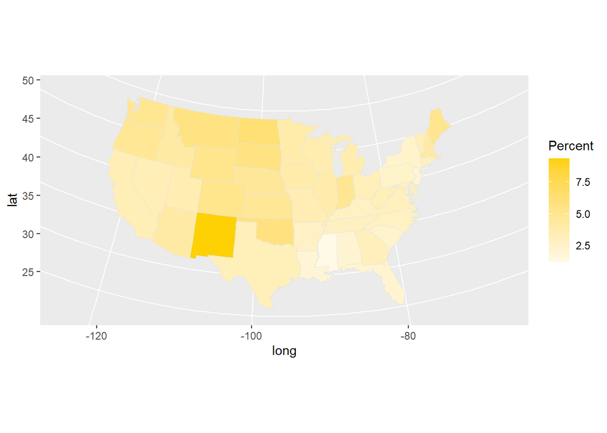

```r
us_states <- map_data("state")
election$region <- tolower(election$state)
us_states_elec <- left_join(us_states, election)
p0 <- ggplot(data = us_states_elec,
             aes(x = long, y = lat, group = group, fill = pct_johnson))

p1 <- p0 + geom_polygon(color = "gray90", size = 0.1) +
    coord_map(projection = "albers", lat0 = 39, lat1 = 45)

p2 <- p1 + scale_fill_gradient2(low = "white",
                                high = "#fed105")
p2 + labs(fill = "Percent")
```

# Activity 2

```r
trees <- read_excel("C:\\Users\\huyeu\\Documents\\GitHub\\cpsc3400\\code\\data3310\\tree_sales.xlsx")
trees <- trees %>%
     rename(
         amount = Amount,
         date = "Close Date",
         zip = "Mailing Zip/Postal Code"
     )
trees$date <- mdy(trees$date)
sales_by_date <- trees %>%
    group_by(date) %>%
    summarise(num = n(), amt = sum(amount))
```

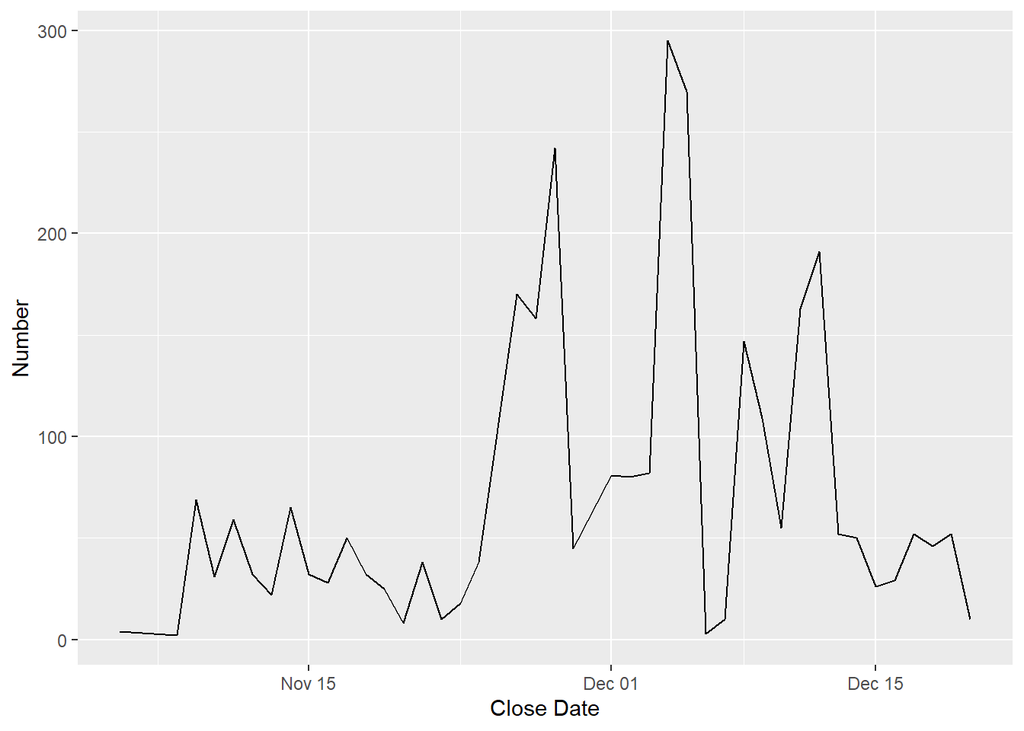

```r
num_sales_vs_date <- ggplot(data = sales_by_date,
                            mapping = aes(x = date, y = num))
num_sales_vs_date + geom_line() + labs(x = "Close Date",
    y = "Number")
```

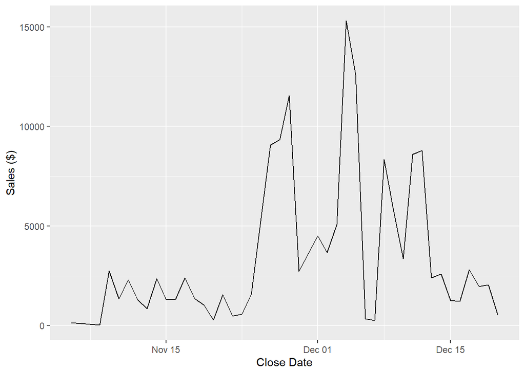

```r
sales_vs_date <- ggplot(data = sales_by_date,
                        mapping = aes(x = date, y = amt))
sales_vs_date + geom_line() + labs(x = "Close Date",
    y = "Sales ($)")
```

```r
zip_code_sales <- trees %>%
    group_by(zip) %>%
    summarise(num = n(), amt = sum(amount))
zip_code_sales <- zip_code_sales[complete.cases(zip_code_sales), ]
zip_code_sales <- zip_code_sales[order(-zip_code_sales$num), ]
```

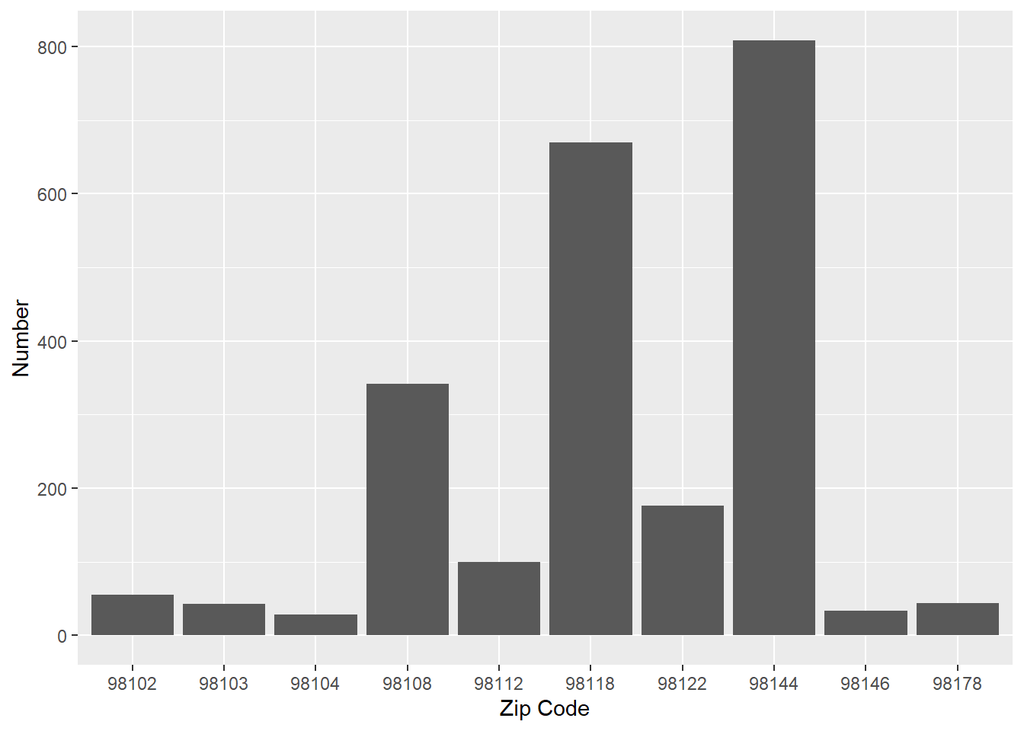

```r
top_ten_zip <- head(zip_code_sales, 10)
num_vs_zip <- ggplot(data = top_ten_zip, aes(x = zip, y = num))
num_vs_zip + geom_col() + labs(x = "Zip Code", y = "Number")
```

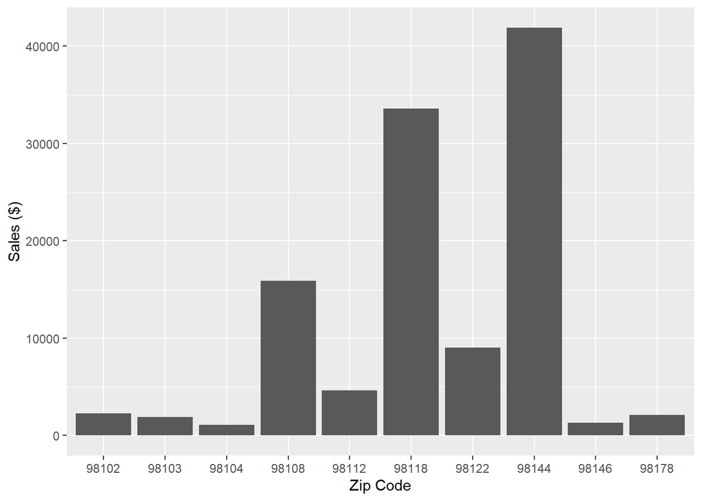

```r
sales_vs_zip <- ggplot(data = top_ten_zip, aes(x = zip, y = amt))
sales_vs_zip + geom_col() + labs(x = "Zip Code", y = "Sales ($)")
```

# Activity 3

```r
full_df <- read.csv("C:\\Users\\huyeu\\Downloads\\Full_2017_ABS_US.csv", na.strings = c("S", "D", "N", "X"))
full_df <- full_df %>%
  rename(
    geo_id = GEO_ID,
    geo_footnote = GEO_ID_F,
    geo_name = NAME,
    naics_code_6_digit = NAICS2017,
    naics_label = NAICS2017_LABEL,
    industry_level = INDLEVEL,
    industry_group = INDGROUP,
    subsector = SUBSECTOR,
    naics_footnote = NAICS2017_F,
    sector = SECTOR,
    sex_code = SEX,
    sex_label = SEX_LABEL,
    ethnicity_code = ETH_GROUP,
    ethnicity_label = ETH_GROUP_LABEL,
    race_code = RACE_GROUP,
    race_label = RACE_GROUP_LABEL,
    vet_code = VET_GROUP,
    vet_label = VET_GROUP_LABEL,
    year = YEAR,
    employer_firms = FIRMPDEMP,
    sales = RCPPDEMP,
    employees = EMP,
    annual_payroll = PAYANN,
    st_err_employer_firms = FIRMPDEMP_S,
    st_err_sales = RCPPDEMP_S,
    st_err_employees = EMP_S,
    st_err_payroll = PAYANN_S
  )

full_df <- full_df[-1,]
full_df$sales <- as.integer(full_df$sales)
full_df$employer_firms <- as.integer(full_df$employer_firms)
full_df$sales_per_firm <- full_df$sales/full_df$employer_firms

sm_df <- full_df %>%
  select(c(naics_code_6_digit, naics_label, sector, sex_label, ethnicity_label, race_label, vet_label, employer_firms, sales, sales_per_firm, st_err_employer_firms, st_err_sales))

full_sector_labels <- c(`11`="Agriculture, Forestry, Fishing, and Hunting", `21`="Mining, Quarrying, and Oil and Gas Extraction", `22`="Utilities", `23`="Construction", `31`="Manufacturing", `42`="Wholesale Trade", `44`="Retail Trade", `48`="Transportation and Warehousing", `51`="Information", `52`="Finance and Insurance", `53`="Real Estate and Rental and Leasing", `54`="Professional, Scientific, and Technical Services", `55`="Management of Companies and Enterprises", `56`="Administrative and Support and Waste Management and Remediation Services", `61`="Educational Services", `62`="Health Care and Social Assistance", `71`="Arts, Entertainment, and Recreation", `72`="Accommodation and Food Services", `81`="Other Services (except Public Administration)")

sector_labels <- c(`11`="Agr.", `21`="Nat. Res.", `22`="Util.", `23`="Constr.", `31`="Manu.", `42`="Whole. Trade", `44`="Ret. Trade", `48`="Transp. & Ware.", `51`="Info.", `52`="Fin. & Ins.", `53`="Real Est.", `54`="Sci. & Tech.", `55`="Mgmt", `56`="Wst. Mgmt", `61`="Educ.", `62`="Hlth. & Soc.", `71`="Arts & Ent.", `72`="Acc. & Food", `81`="Other")

sector_labeller <- as_labeller(sector_labels)

model_colors <- brewer.pal(8,"Dark2")
model_colors
```

```
## [1] "#1B9E77" "#D95F02" "#7570B3" "#E7298A" "#66A61E" "#E6AB02" "#A6761D"
## [8] "#666666"
```

1. Employees by sector

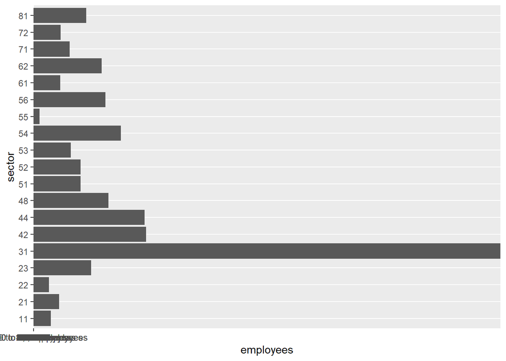

```r
employeesBySector <- full_df %>%
  select(sector, employees) %>%
  group_by(sector)

p <- ggplot(data = employeesBySector, mapping = aes(x = sector, y = employees))
p + geom_col() + coord_flip()
```

The graph shows the comparative number of employees for each sector. Sector 31, manufacturing, has much more employees than the other sectors.

2. Employees by race by sector

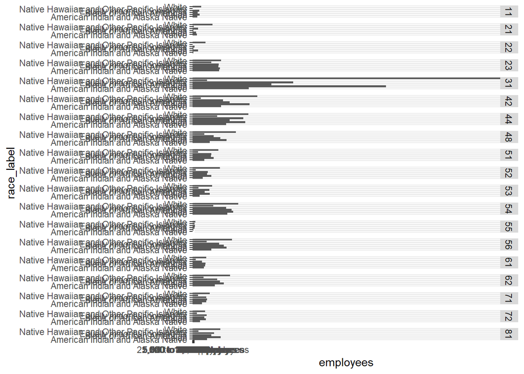

```r
race_by_sector <- full_df %>%
    filter(race_code != 98 & race_code != 96 & race_code != 92 & race_code != 90 & race_label != "Total" & race_label != "Meaning of Race code")
p <- ggplot(data = race_by_sector,
    mapping = aes(x = race_label, y = employees))
p + geom_col() + coord_flip() + facet_grid(sector ~ .)
```

From this graph, most sectors have mostly white-owned businesses. Sector 31 has a much higher number of white-owned businesses than other races. Sectors 23 (construction) and 55 (management of companies and enterprises) are the most even across all the races.

3. Employees by gender by sector

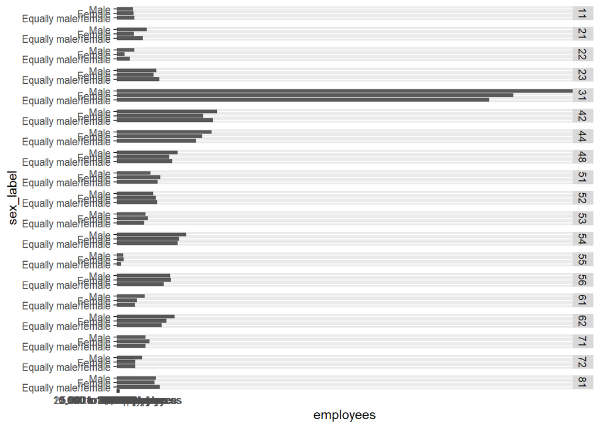

```r
gender_by_sector <- full_df %>%
    filter(sex_label == "Female" | sex_label == "Male"
          | sex_label == "Equally male/female")
p <- ggplot(data = gender_by_sector,
    mapping = aes(x = sex_label, y = employees))
p + geom_col() + coord_flip() + facet_grid(sector ~ .)
```

4. Mean average sales per firm by race and sector

```r
salespf_sector <- sm_df %>%
  select(sector, sales_per_firm, race_label) %>%
  group_by(sector, race_label) %>%
  filter(race_label!="Unclassifiable", race_label!="Total", race_label!="Classifiable", race_label!="Minority", race_label!="Nonminority", race_label!="Equally minority/nonminority") %>%
  summarise(mean = mean(sales_per_firm, na.rm=T))
```

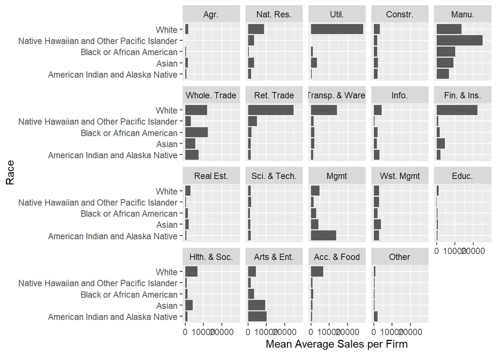

```r
p <- ggplot(data = salespf_sector, mapping = aes(x = race_label, y = mean))
p + geom_col(position="dodge") + facet_wrap(sector ~ ., scales = "fixed", labeller = sector_labeller) + coord_flip() + labs(x="Race", y="Mean Average Sales per Firm")
```

# Activity 4

```r
race_by_sector <- full_df %>%
    filter(race_code != 98 & race_code != 96 & race_code != 92 & race_code != 90 & race_label != "Total" & race_label != "Meaning of Race code")
race_by_sector <- race_by_sector %>%
    group_by(sector, race_label) %>%
    summarise(num = n())
```

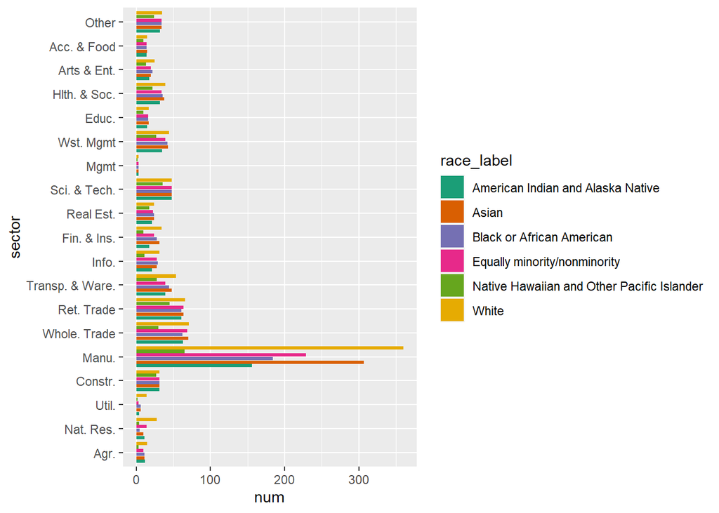

```r
p <- ggplot(data = race_by_sector,
    mapping = aes(x = sector, y = num, fill = race_label))
p + geom_col(position = "dodge2") + coord_flip() +
    scale_x_discrete(labels = sector_labels) +
    scale_fill_manual(values = model_colors)
```

```r
gender_by_sector <- full_df %>%
    filter(sex_label == "Female" | sex_label == "Male"
          | sex_label == "Equally male/female")
gender_by_sector <- gender_by_sector %>%
    group_by(sector, sex_label) %>%
    summarise(num = n())
```

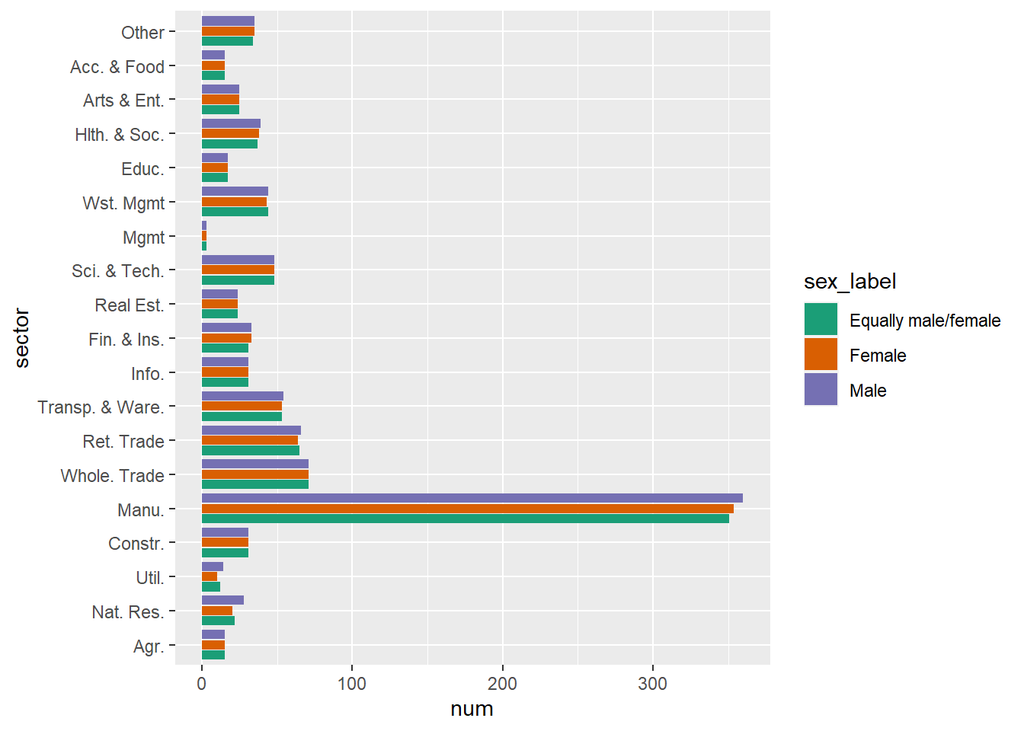

```r
p <- ggplot(data = gender_by_sector,
    mapping = aes(x = sector, y = num, fill = sex_label))
p + geom_col(position = "dodge2") + coord_flip() +
    scale_x_discrete(labels = sector_labels) +
    scale_fill_manual(values = model_colors)
```

3. Mean average total sales by race in each sector with separate bars

```r
sales_sector <- sm_df %>%
  select(sector, sales, race_label) %>%
  filter(race_label!="Unclassifiable", race_label!="Total", race_label!="Classifiable", race_label!="Minority", race_label!="Nonminority", race_label!="Equally minority/nonminority") %>%
  group_by(sector, race_label) %>%
  summarise(mean = mean(sales, na.rm = T))
```

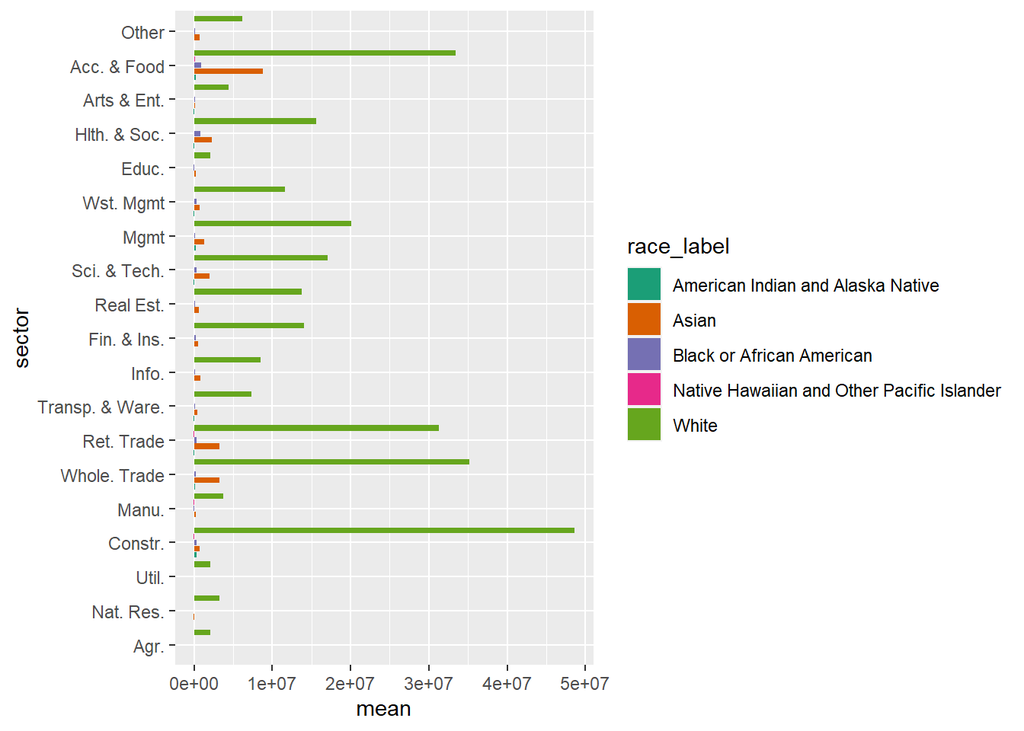

```r
  p <- ggplot(data = sales_sector, mapping = aes(x = sector, y = mean, fill=race_label))

p + geom_col(position = "dodge2") + coord_flip() +
    scale_fill_manual(values = model_colors) +
    scale_x_discrete(labels = sector_labels)
```

4. Sales by sector using a bar graph

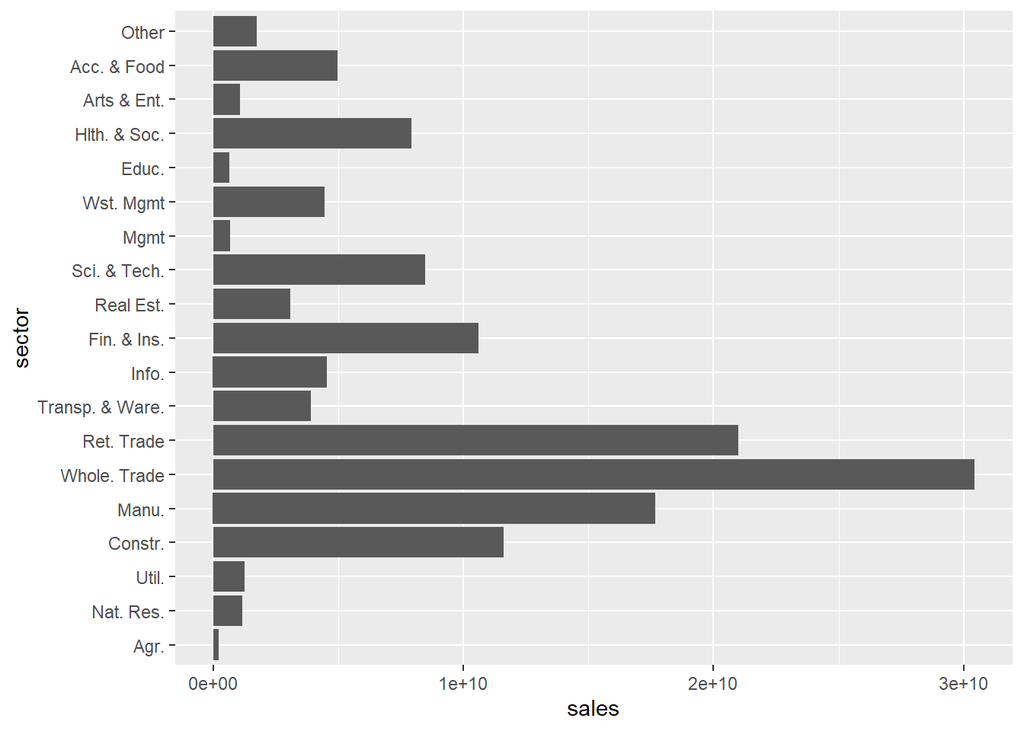

```r
salesBySector <- full_df %>%
  select(sector, sales) %>%
  group_by(sector)

p <- ggplot(data = salesBySector,
        mapping = aes(x = sector, y = sales))
p + geom_col() + coord_flip() +
    scale_x_discrete(labels = sector_labels)
```

# Activity 5

1. How can we better scale the axes for things like sales to make them easier to read/understand?
2. When should we use the standard error for number of firms, sales, payroll, etc?
3. Should percentages be used when dividing data by sector, since some sectors have more businesses?
4. How could we look at data by NAICS code when there’s so many different codes?